# Fenômenos de Transporte

*Prof. Tito Dias Júnior*

### Transferência de calor entre duas placas isotérmicas

### **Exemplo:**

Considere transferência de calor, em regime permanente, entre duas grandes placas paralelas com temperaturas uniformes de $300 K$ e $200 K$ separadas por $1 cm$, como mostradas na Figura abaixo. Supondo que as superfícies se comportem como corpo negro (emissividade 1), determine a taxa de transferência de calor entre as placas por unidade de superfície, assumindo que o espaço entre as placas é (a) preenchido com ar atmosférico, (b) evacuado, (c) preenchido com isolamento de poliutretano, e (d) preenchido com superisolante térmico com condutividade térmica de $0,00002 W / m · ° C.$

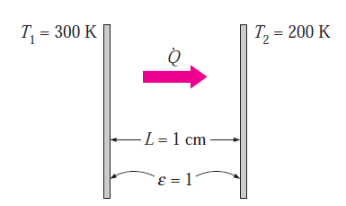

```python
from IPython.display import Image
Image("diagrama.png")
```

```python
L = 1E-2    # Distância de 1cm
e = 1       # Emissividade
T1 = 300    # Temperatura em kelvin
T2 = 200    # Temperatura em kelvin
A = 1       # Área entre as placas igual a um, pois pede-se a transf. de calor por unidade de superfície
```

## Solução

A taxa total de transferência de calor entre duas placas isotérmicas paralelas com dimensões maiores que a distância entre elas deve ser determinada para quatro casos diferentes.

### Hipóteses

1. Regime permanente.
2. Despreza-se a convecção natural
3. As superfícies se comportam como corpos negros

### Propriedades - Condutividades térmicas

1. Ar a 250K: $$ k=0,0219 W/m ° C $$
2. Poliuretano: $$k=0,026 W/m°C$$
3. Superisolante térmico: $$k= 0,00002 W/m°C $$

```python
k_ar = 0.0219
k_poli = 0.026
k_super = 0.00002
```

### Análise

As taxas de transferência de calor por condução e por radiação entre as placas através do meio que preenche o espaço entre elas são:

$ \dot{Q_{cond}}=kA\frac{T_1 - T_2}{L}$

```python
# Definindo a função que calcula a taxa de transf. de calor por CONDUÇÃO
def Qcond(k,A,L,T1,T2):
    Qcond=k*A*(T1-T2)/L
    return Qcond
```

$ \dot{Q_{rad}}=\epsilon \sigma A (T_1^4 - T_2^4)$

```python
# Definindo a função que calcula a taxa de transf. de calor por RADIAÇÃO
def Qrad(e,A,T1,T2):
    sigma = 5.67E-8 #Constate de Stefan-Boltzmann
    Qrad= e*sigma*A*(T1**4-T2**4)
    return Qrad
```

E a taxa de transferência total corresponde à soma $\dot{Q_{total}}=\dot{Q_{cond}}+\dot{Q_{rad}}$

(A) As taxas de condução e transferência de calor por radiação entre as placas através da camada de ar são:

```python
Qar = Qcond(k_ar,A,L,T1,T2) + Qrad(e,A,T1,T2)
print('Qcond =',Qcond(k_ar,A,L,T1,T2),' e Qrad =',Qrad(e,A,T1,T2))
print('Qar =', Qar, 'kW/m^2')
```

```
Qcond = 219.0  e Qrad = 368.55
Qar = 587.55 kW/m^2
```

(B) As taxas de condução e transferência de calor por radiação entre as placas evacuadas:

```python
Qar = 0 + Qrad(e,A,T1,T2)
print('Qcond =',0,' e Qrad =',Qrad(e,A,T1,T2))
print('Qar =', Qar, 'kW/m^2')
```

```
Qcond = 0  e Qrad = 368.55
Qar = 368.55 kW/m^2
```

(C) As taxas de condução e transferência de calor por radiação entre as placas através do poliuretano:

```python
Qar = Qcond(k_poli,A,L,T1,T2) + 0
print('Qcond =',Qcond(k_poli,A,L,T1,T2),' e Qrad =',0)
print('Qar =', Qar, 'kW/m^2')
```

```
Qcond = 260.0  e Qrad = 0
Qar = 260.0 kW/m^2
```

(D) As taxas de condução e transferência de calor por radiação entre as placas através do superisolante:

```python
Qar = Qcond(k_super,A,L,T1,T2) + 0
print('Qcond =',Qcond(k_super,A,L,T1,T2),' e Qrad =',0)
print('Qar =', Qar, 'kW/m^2')
```

```
Qcond = 0.2  e Qrad = 0
Qar = 0.2 kW/m^2
```

## Referência

Çengel, Y. A., Turner, R. H., & Cimbala, J. M. (2008). **Fundamentals of thermal-fluid sciences**. Boston: McGraw-Hill.